# DECOVID Data Evaluation Report

Ed Palmer

May 27, 2022

## Schema Checks

This is a mid-stream quality evaluation and **does not** check for schema conformity. This should be conducted separately through the application of the DECOVID-OMOP dll file constraints. It is assumed that these have been applied successfully before running this report.

## Structural Checks

Check that all visit_occurrence_id is populated: TRUE

Row counts for core clinical tables:

| table | n |
| --- | --- |
| condition_occurrence | 127599 |
| death | 29681 |
| device_exposure | 0 |
| drug_exposure | 119139 |
| measurement | 2606417 |
| observation | 1244214 |
| person | 139802 |
| procedure_occurrence | 62282 |
| specimen | 0 |
| visit_detail | 139802 |
| visit_occurrence | 139802 |

The proportion of *missing* data is shown. Sometimes is can be entirely appropriate. Rows are shown in **red** if they have a higher level of missingness than acceptable tolerances.

| table | column | n rows missing | % rows missing | tolerance |
| --- | --- | --- | --- | --- |
| person | person_id | 0 | 0 | 0.0 |
| person | gender_concept_id | 0 | 0 | 0.5 |
| person | year_of_birth | 0 | 0 | 0.5 |
| person | month_of_birth | 139802 | 100 | 100.0 |
| person | day_of_birth | 139802 | 100 | 100.0 |
| person | birth_datetime | 139802 | 100 | 100.0 |
| person | race_concept_id | 0 | 0 | 0.0 |
| person | ethnicity_concept_id | 0 | 0 | 100.0 |
| person | location_id | 139802 | 100 | 1.0 |
| person | provider_id | 139802 | 100 | 100.0 |
| person | care_site_id | 0 | 0 | 100.0 |
| visit_occurrence | visit_occurrence_id | 0 | 0 | 0.0 |
| visit_occurrence | person_id | 0 | 0 | 0.0 |
| visit_occurrence | visit_concept_id | 0 | 0 | 0.0 |
| visit_occurrence | visit_start_date | 0 | 0 | 0.0 |
| visit_occurrence | visit_start_datetime | 114 | 0 | 0.0 |
| visit_occurrence | visit_end_date | 0 | 0 | 2.0 |
| visit_occurrence | visit_end_datetime | 39934 | 29 | 2.0 |
| visit_occurrence | visit_type_concept_id | 0 | 0 | 100.0 |
| visit_occurrence | provider_id | 139802 | 100 | 100.0 |
| visit_occurrence | care_site_id | 139802 | 100 | 100.0 |
| visit_occurrence | discharge_to_concept_id | 139802 | 100 | 5.0 |
| visit_occurrence | preceding_visit_occurrence_id | 139802 | 100 | 100.0 |
| visit_detail | visit_detail_id | 0 | 0 | 0.0 |
| visit_detail | person_id | 0 | 0 | 0.0 |
| visit_detail | visit_detail_concept_id | 0 | 0 | 100.0 |
| visit_detail | visit_detail_start_date | 0 | 0 | 0.0 |
| visit_detail | visit_detail_start_datetime | 162 | 0 | 0.0 |
| visit_detail | visit_detail_end_date | 0 | 0 | 2.0 |
| visit_detail | visit_detail_end_datetime | 300 | 0 | 2.0 |
| visit_detail | visit_detail_type_concept_id | 0 | 0 | 100.0 |
| visit_detail | provider_id | 139802 | 100 | 100.0 |
| visit_detail | care_site_id | 0 | 0 | 0.0 |
| visit_detail | discharge_to_concept_id | 139802 | 100 | 100.0 |
| visit_detail | preceding_visit_detail_id | 139802 | 100 | 100.0 |
| visit_detail | visit_detail_parent_id | 139802 | 100 | 100.0 |
| visit_detail | visit_occurrence_id | 0 | 0 | 0.0 |
| death | person_id | 0 | 0 | 0.0 |
| death | death_date | 49 | 0 | 0.0 |
| death | death_datetime | 631 | 2 | 100.0 |
| death | death_type_concept_id | 0 | 0 | 100.0 |
| death | cause_concept_id | 29681 | 100 | 100.0 |

## Person Table

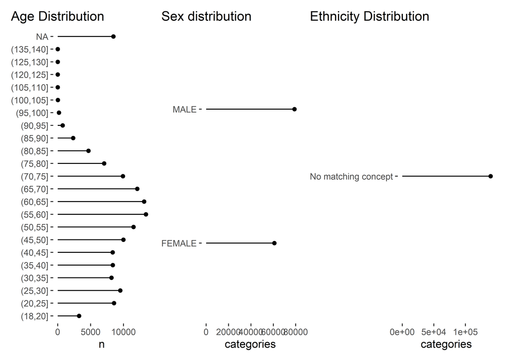

Madatory checks

- Minimum age >= 18: FALSE

## Visit Characteristics

Date boundaries of the cohort:

| observation | time | comparison | tolerance |
| --- | --- | --- | --- |
| first_visit_date | 0002-03-15 00:00:00 | 2020-01-01 00:00:00 | fail |
| first_visit_dttm | 0002-03-15 20:23:00 | 2020-01-01 00:00:00 | fail |
| last_visit_date | 2118-05-14 00:00:00 | 2022-05-27 12:32:44 | fail |
| last_visit_dttm | 2118-05-14 00:00:00 | 2022-05-27 12:32:44 | fail |
| first_dc_date | 2001-01-13 00:00:00 | 2020-01-01 00:00:00 | fail |
| first_dc_dttm | 2001-01-13 05:32:00 | 2020-01-01 00:00:00 | fail |
| last_dc_date | 2022-04-18 00:00:00 | 2022-05-27 12:32:44 | pass |
| last_dc_dttm | 2022-04-18 18:10:00 | 2022-05-27 12:32:44 | pass |

Number of visits stratified by visit type:

| visit_concept_id | count | percentage |
| --- | --- | --- |
| Inpatient Visit | 139802 | 100 |

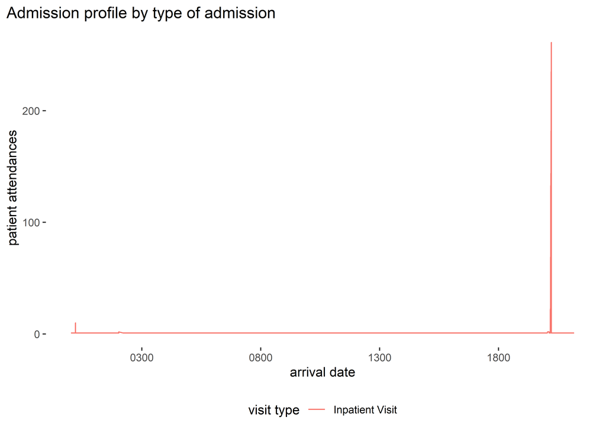

Admission codes outside the approved list:

| admitting_source_concept_id | n |
| --- | --- |
| NA | 139802 |

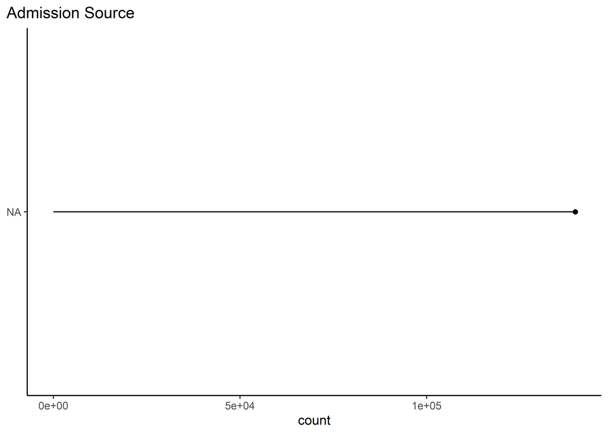

Discharge codes outside the approved list:

| discharge_to_concept_id | n |
| --- | --- |
| NA | 139802 |

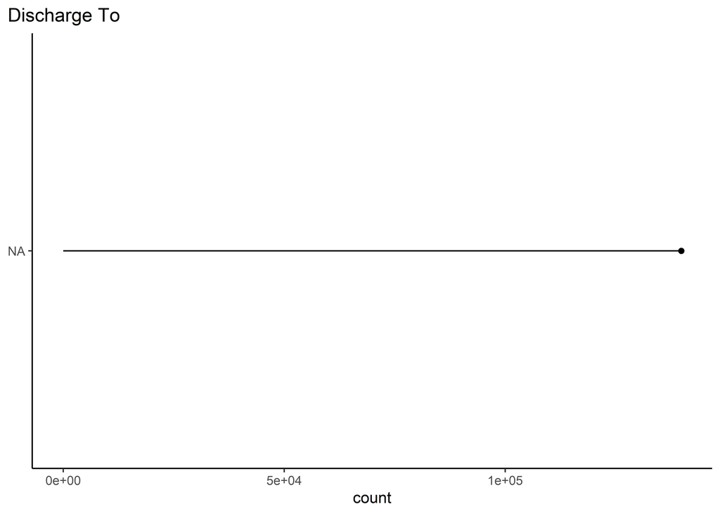

All deaths inside the hospital should be aligned with the final visit end datetime. This is an OMOP convention and doesn’t necessarily mean the data is bad.

```
#> [1] 61
```

All records that have a discharge recorded at “Patient died” should also have a death record in the death table.

| death_record | n |
| --- | --- |

Deviations of more than 24 hours (by datetime) or 48 hours (by date) should be investigated:

| tolerance test | n | % | tolerance |
| --- | --- | --- | --- |
| death 24 hrs < visit end (dttm) | 0 | NaN | 5 |
| death within tolerance (dttm) | 0 | NaN | 90 |
| death 24 hrs > visit end (dttm) | 0 | NaN | 5 |
| death 48 hrs < visit end (date) | 0 | NaN | 5 |
| death within tolerance (date) | 0 | NaN | 90 |
| death 48 hrs > visit end (date) | 0 | NaN | 5 |

[figure not shown]

## Visit Occurrence

Are all visits ordered sequentially:

| overlap | n |
| --- | --- |
| FALSE | 139802 |

What are the lengths of stay:

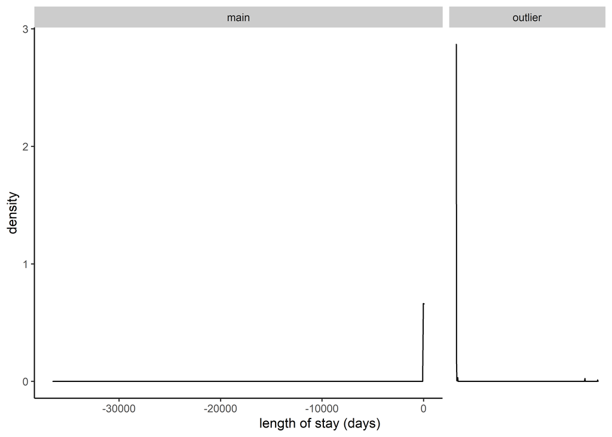

| length of stay | tolerance | n | % |
| --- | --- | --- | --- |
| negative | 1 | 707 | 1 |
| zero | 1 | 47 | 0 |
| positive | 99 | 99021 | 71 |
| missing los data | 1 | 40027 | 29 |

## Readmissions

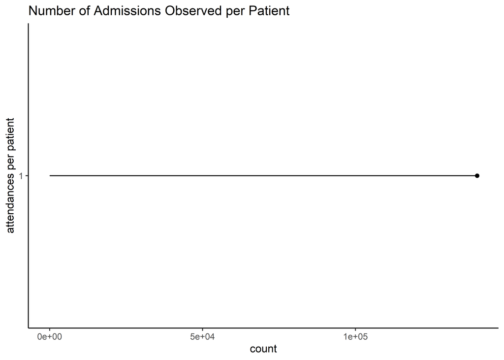

## Visit Detail

Are all visits ordered sequentially:

| overlap | n |
| --- | --- |
| FALSE | 139802 |

What are the lengths of stay:

| length of stay | tolerance | n | % |
| --- | --- | --- | --- |
| negative | 1 | 1161 | 1 |
| zero | 1 | 122 | 0 |
| positive | 99 | 138083 | 99 |
| missing los data | 1 | 436 | 0 |

## Outcomes

The following list the outcomes for patients attending at **ccaa**:

| death | n | total | % |
| --- | --- | --- | --- |
| Inpatient Visit |  |  |  |
| FALSE | 110752 | 139802 | 79 |
| TRUE | 29050 | 139802 | 21 |

## Distributions of Times

Typically patients are admitted earlier in the day, and discarged later. Death often has a uniform distribution, with perhaps a slight peak in the early morning or later afternoon.

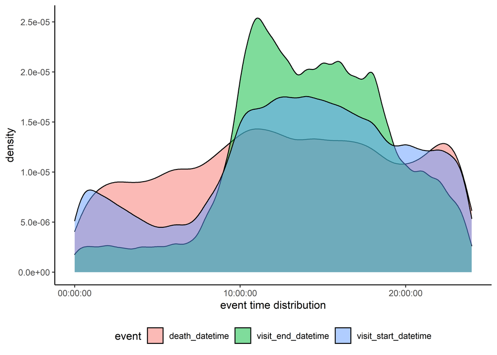

## Specimen Table

Unique specimen concepts:

Unique anatamical sites:

## Drug Exposure Table

The top 50 most common drugs given:

| drug_concept_id | n |
| --- | --- |
| ceftriaxone | 22036 |
| meropenem | 14340 |
| tazobactam | 14322 |
| piperacillin | 13696 |
| Corticosteroids | 13186 |
| NA | 4874 |
| azithromycin | 4129 |
| cefoperazone | 3792 |
| sulbactam | 3272 |
| cefuroxime | 2699 |
| amoxicillin | 2143 |
| omeprazole | 1917 |
| imipenem | 1686 |
| cilastatin | 1686 |
| norepinephrine | 1320 |
| ceftazidime | 1144 |
| cefotaxime | 1083 |
| Intravenous | 1063 |
| pantoprazole | 1041 |
| levofloxacin | 960 |
| moxifloxacin | 888 |
| clindamycin | 807 |
| amikacin | 775 |
| cefepime | 584 |
| clavulanic acid | 581 |
| penicillin G | 574 |
| penicillin V | 574 |
| cefazolin | 530 |
| Heparin therapy | 528 |
| linezolid | 409 |
| acyclovir | 303 |
| teicoplanin | 275 |
| Subcutaneous | 233 |
| fluconazole | 180 |
| tigecycline | 158 |
| ranitidine | 155 |
| Oral administration of treatment | 139 |
| epinephrine | 107 |
| dopamine | 104 |
| No matching concept | 90 |
| floxacillin | 87 |
| voriconazole | 87 |
| gentamicin | 63 |
| esomeprazole | 63 |
| sulfamethoxazole | 59 |
| trimethoprim | 59 |
| ertapenem | 55 |
| dobutamine | 44 |
| erythromycin | 44 |
| fosfomycin | 42 |

## Condition Occurrence Table

The top 20 most common conditions:

| condition_concept_id | n |
| --- | --- |
| No matching concept | 42106 |
| Severe acute respiratory infection | 32602 |
| Pneumonia caused by SARS-CoV-2 | 5064 |
| Sepsis | 2539 |
| Septic shock | 1069 |
| Pneumonia | 1029 |
| COVID-19 | 825 |
| Triple vessel disease of the heart | 759 |
| Chronic kidney disease | 756 |
| Acute respiratory distress syndrome due to disease caused by Severe acute respiratory syndrome coronavirus 2 | 754 |
| Acute myocardial infarction of anterior wall | 716 |
| Cerebrovascular accident | 696 |
| Injury of head | 528 |
| Viral pneumonia | 524 |
| Poisoning | 495 |
| Urinary tract infectious disease | 488 |
| Diabetes mellitus | 459 |
| Dengue | 429 |
| Acute respiratory distress syndrome | 425 |
| Diabetic ketoacidosis | 423 |

Condition types seen:

| condition_type_concept_id | n |
| --- | --- |
| Registry | 127599 |

Condition status seen:

| condition_status_concept_id | n |
| --- | --- |
| NA | 127599 |

## Procedure Occurrence Table

All procedures seen:

| procedure_concept_id | n |
| --- | --- |
| Cardiac monitoring | 21878 |
| No matching concept | 14956 |
| Renal replacement | 5322 |
| Assisted ventilation in prone position | 5077 |
| Laparotomy | 1153 |
| Cesarean section | 878 |
| Trial for spontaneous breathing | 791 |
| Exploratory laparotomy | 695 |
| Craniotomy | 600 |
| Open heart surgery | 460 |
| Coronary artery bypass graft | 425 |
| Antenatal 38 week examination | 351 |
| Heated and humidified high flow oxygen therapy | 263 |
| Road traffic accident injury examination | 239 |
| Percutaneous transluminal coronary angioplasty | 223 |
| Replacement of mitral valve | 207 |
| Appendectomy | 181 |
| Coronary artery bypass grafts x 3 | 170 |
| Lower uterine segment cesarean section | 146 |
| Replacement of aortic valve | 134 |
| Cholecystectomy | 133 |
| Excision | 130 |
| Hysterectomy | 127 |
| Abdominal paracentesis | 112 |
| Evacuation of subdural hematoma | 97 |
| Debridement of wound of skin | 95 |
| Laparoscopic cholecystectomy | 94 |
| Transplantation of liver | 89 |
| Pancreaticoduodenectomy | 88 |
| Craniotomy and excision of neoplasm of brain | 86 |

[output cut: 1907 more lines]

## Fact Relationship

- check that all the relationships are listed both ways around
- check how many:
  - specimens link to measurements
  - how many terminal branch (metadata) tags we have

| relationship_concept_id | n |
| --- | --- |